# Undrestanding the Enrollment Rate Drop in Key Account Motion

Joyvalerie Mondejar**, **Nikko Joe Ramal

January 24, 2019

# Introduction

The ventures team of the Positioning and Messaging Motion Initiative have access to the monthly motion report which provides current and past year month enrollment and participation statistics. It has been noticed in these reports that although the enrollment rate in the Motion Program has increased between 2017 and 2018, there was a substancial drop in the enrollment rate for the Key Accounts Motion from 64% in July 2017 to 42% in July 2018. There was a suspicion that the observation might be connected to a shift from bulk-shipping devices to directly shipping devices to members’ homes. Also, there was a dramatic drop in the percent of active among those enrolled members.

With these findings, it is important to establish and understand the characteristics that exist between the members from July 2017 and July 2018 to better guide the future motion enrollment and engagement efforts. Through this grant, we would like to compare the member characteristics, particularly those related to health between those 1) enrolled and 2) actively walking among those enrolled in July 2017 and in July 2018.

# Methods

This grant used the healthcare claims and motion data for Key Account motion eligible members. The two groups that were compared were those members of employers eligible for Key Account motion program in July 2017 and those that were eligible in July 2018. The monthly data going back to one year prior of the current year month were also gathered. For consistency, the researchers have used the same definitions of eligible, enrolled, and active as in the monthly motion report, i.e., had at least 100 steps during at least one day and do not have an incentive adjustment less than $40 during the month. The researchers conducted several analyses to examine the differences between enrolled members in July 2018 compared to those enrolled in July 2017.

**Data cleaning done**

- Those individuals not enrolled in UHC plan were removed.
- Row records which do not belong to either groups were removed.
- Members not associated with Key Account motion were also removed.
- We also suspected that members younger than 18 years old are not eligible to Key Account motion program.
- Duplicates were removed.
- Gender that were ‘U’ were converted to NAs.
- Median household income that is 0 were converted to NAs.
- RAF scores that were 0 were converted to NAs.
- Missing or negative allowed amounts were replaced with 0.

Numerical variables such as age, median household income, RAF score, and allowed amounts were compared using independent-samples t-test between the two groups. Categorical variables such as gender, subscriber indicator, area of residence, condition diagnoses were compared using chi-squared test between the two groups. Median household income and spending amounts that lie beyond 99.5 percentile of their normalised values were removed before the analyses. RAF scores that lie beyond 99.9 percentile of their normalised values were removed before the analyses. If the proportions are significantly different between the two groups, the size of the difference is quantified using Cohen’s h. Hedges’ g was used to quantify the effect size of statistically different means between the two groups.

# Results

To better understand the enrollment drop in Key Accounts Motion, we examined the differences of eligible, enrolled and active among eligible and enrolled members between July 2017 and July 2018. We compared these groups with regard to patient demographics, certain disease conditions, and healthcare costs.

## Eligibility and Enrollment

Key Account motion enrollment rate dropped from 69.1% in July 2017 down to 45.8% in July 2018. There are discrepancies in the counts of eligible members as well as the enrolled members largely because the monthly motion report included those members who were not enrolled with any UHG plan and those that were not eligible to Key Account motion, i.e., either associated with small business or public accounts. The reason being was that some of the individuals’s identity from the AWS motion data did not match with the PHI of individuals from NGIS.

| Enrollment Rate Year_Mo | Enrollment Rate Eligible | Enrollment Rate Enrolled | Enrollment Rate % |
| --- | --- | --- | --- |
| Group 1 |  |  |  |
| 201707 | 14071 | 9730 | 69.1 |
| Group 2 |  |  |  |
| 201807 | 36438 | 16672 | 45.8 |

There were 7,747 eligible members in July 2017 that were still eligible in July 2018 and there were 5,728 members enrolled in both year months.

## Eligible

### Demographics

- Eligible members in July 2018 were about a year younger than those eligible in July 2017. However, this is a negligible difference.
- There are more females in July 2018 than in July 2017.
- There are more who lives in suburban areas and less in rural areas among the July 2018 eligible members.
- The household median income of eligible members in July 2018 is $1051 more than the income of eligible members in July 2017. The effect size is 0.044, a negligible estimate.

Demographics profile of those who were eligible for Key Account motion program

|  | July 2017 (N=14071) | July 2018 (N=36438) | p value |
| --- | --- | --- | --- |
| **Age** |  |  | < 0.001 |
| Median (Q1, Q3) | 44.00 (35.00, 54.00) | 43.00 (33.00, 54.00) |  |
| Mean (SD) | 44.58 (11.89) | 43.57 (12.12) |  |
| Range | 19.00 - 85.00 | 18.00 - 94.00 |  |
| **Gender** |  |  | < 0.001 |
| N-Miss | 0 | 7 |  |
| F | 6556 (46.6%) | 18593 (51.0%) |  |
| M | 7515 (53.4%) | 17838 (49.0%) |  |
| **Subscriber** | 11177 (79.4%) | 28770 (79.0%) | 0.237 |
| **Area** |  |  | < 0.001 |
| N-Miss | 30 | 47 |  |
| U | 4364 (31.1%) | 11839 (32.5%) |  |
| S | 6017 (42.9%) | 16790 (46.1%) |  |
| R | 3660 (26.1%) | 7762 (21.3%) |  |
| **Median Household Income** |  |  | < 0.001 |
| N | 14037 | 36375 |  |
| N-Miss | 34 | 63 |  |
| Median (Q1, Q3) | 56028.00 (44167.00, 73602.00) | 57015.00 (44583.00, 75077.00) |  |
| Mean (SD) | 61004.91 (23145.73) | 62052.30 (23935.88) |  |
| Range | 11021.00 - 217171.00 | 11021.00 - 250001.00 |  |

Effect size of the difference

| Variable | Estimate | Magnitude |
| --- | --- | --- |
| Female | 0.089 | negligible |
| Suburban | 0.066 | negligible |
| Rural | 0.112 | negligible |

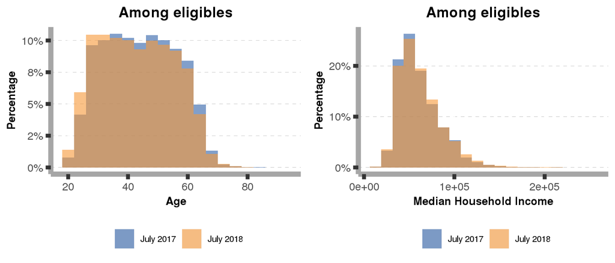

### Health

- Prevalence of disease conditions do not differ between the two groups.
- The RAF scores of July 2018 eligible members is 0.14 lower than those of July 2017 eligible members. The effect size is 0.105, a negligible estimate.

RAF score and percentage prevalence

|  | July 2017 (N=14071) | July 2018 (N=36438) | p value |
| --- | --- | --- | --- |
| **Type 2 Diabetes** | 80 (0.6%) | 194 (0.5%) | 0.620 |
| **Hypertension** | 392 (2.8%) | 1052 (2.9%) | 0.541 |
| **Depression / Anxiety** | 246 (1.7%) | 695 (1.9%) | 0.236 |
| **COPD** | 21 (0.1%) | 55 (0.2%) | 0.965 |
| **CHF** | 12 (0.1%) | 37 (0.1%) | 0.599 |
| **RA** | 5 (0.0%) | 15 (0.0%) | 0.775 |
| **Chronic Pain** | 498 (3.5%) | 1327 (3.6%) | 0.580 |
| **RAF Score** |  |  | < 0.001 |
| N-Miss | 0 | 7 |  |
| Median (Q1, Q3) | 0.49 (0.29, 0.73) | 0.49 (0.29, 0.70) |  |
| Mean (SD) | 1.29 (4.37) | 1.08 (3.56) |  |
| Range | 0.14 - 185.14 | 0.14 - 185.14 |  |

RAF score (excluding 0.1% extreme normalized values)

|  | July 2017 (N=14071) | July 2018 (N=36438) | p_value |
| --- | --- | --- | --- |
| **RAF Score** |  |  | < 0.001 |
| Nmiss | 0 | 7 |  |
| N-outliers | 154 | 399 |  |
| Median (Q1, Q3) | 0.49 (0.29, 0.70) | 0.49 (0.29, 0.70) |  |
| Mean (SD) | 0.93 (1.55) | 0.79 (1.22) |  |
| Range | 0.14 - 14.66 | 0.14 - 12.06 |  |

To examine the prevalence further, continuous UHC plan enrollment from January to July of the corresponding year was considered. The prevalence of diseases still do not significantly differ between the two groups.

Jan - July percentage prevalence

|  | July 2017 (N=14071) | July 2018 (N=36438) | p value |
| --- | --- | --- | --- |
| **T2D_Flag** | 80 (0.6%) | 194 (0.5%) | 0.620 |
| **Hypertension_Flag** | 1377 (9.8%) | 3657 (10.0%) | 0.400 |
| **Dep_Anx_Flag** | 868 (6.2%) | 2416 (6.6%) | 0.059 |
| **COPD_Flag** | 79 (0.6%) | 188 (0.5%) | 0.527 |
| **CHF_Flag** | 39 (0.3%) | 93 (0.3%) | 0.665 |
| **RA_Flag** | 18 (0.1%) | 43 (0.1%) | 0.774 |
| **ChronicPain_Flag** | 1515 (10.8%) | 4002 (11.0%) | 0.485 |

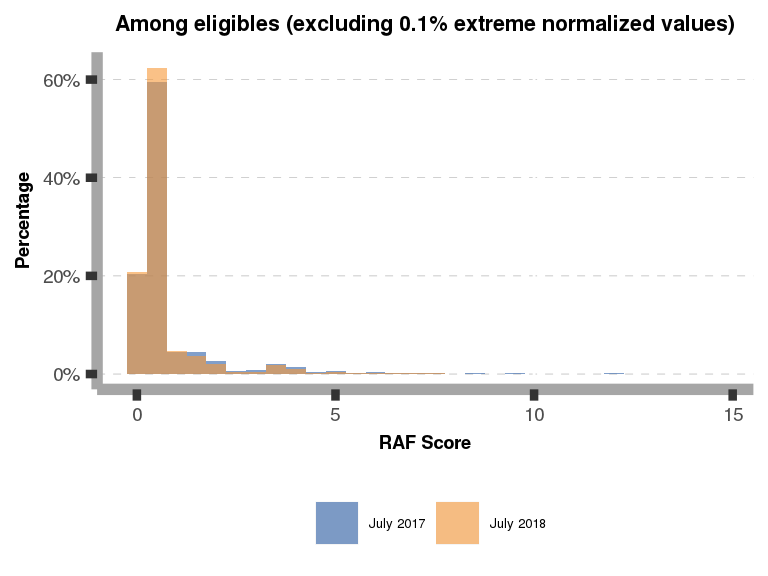

### Claims

On the average, the eligible members in July 2018 have had higher total spend as well as spending for OP and DR visits. However, the effect sizes in the table below suggests that the differences are negligible.

Comparison of healthcare $ spending

|  | July 2017 (N=14071) | July 2018 (N=36438) | p value |
| --- | --- | --- | --- |
| **IP** |  |  | 0.580 |
| Mean (SD) | 113.37 (2392.77) | 100.92 (2215.64) |  |
| Range | 0.00 - 167765.80 | 0.00 - 135134.21 |  |
| **OP** |  |  | 0.211 |
| Mean (SD) | 103.93 (893.53) | 117.93 (1204.90) |  |
| Range | 0.00 - 22388.46 | 0.00 - 47591.66 |  |
| **DR** |  |  | 0.041 |
| Mean (SD) | 75.65 (333.57) | 83.04 (375.35) |  |
| Range | 0.00 - 13958.04 | 0.00 - 17708.18 |  |
| **Rx** |  |  | 0.302 |
| Mean (SD) | 74.66 (633.65) | 81.45 (673.22) |  |
| Range | 0.00 - 31374.00 | 0.00 - 43389.15 |  |
| **ER** |  |  | 0.775 |
| Mean (SD) | 32.82 (355.18) | 33.83 (356.76) |  |
| Range | 0.00 - 11734.61 | 0.00 - 14119.08 |  |
| **Total** |  |  | 0.555 |
| Mean (SD) | 400.43 (2844.94) | 417.12 (2849.43) |  |
| Range | 0.00 - 167765.80 | 0.00 - 136078.69 |  |

Comparison of healthcare $ spending (exluding 0.5% extreme normalized values)

|  | July 2017 (N=14071) | July 2018 (N=36438) | p_value |
| --- | --- | --- | --- |
| **IP** |  |  | 0.338 |
| N-outliers | 59 | 134 |  |
| Mean (SD) | 1.61 (85.34) | 0.98 (57.96) |  |
| Range | 0 - 6220.5 | 0 - 5633.94 |  |
| **OP** |  |  | < 0.001 |
| N-outliers | 135 | 298 |  |
| Mean (SD) | 30.41 (152.37) | 38.12 (202.61) |  |
| Range | 0 - 2400.36 | 0 - 3205.35 |  |
| **DR** |  |  | < 0.001 |
| N-outliers | 191 | 484 |  |
| Mean (SD) | 47.67 (121.45) | 52.18 (130.31) |  |
| Range | 0 - 933.25 | 0 - 1043.6 |  |
| **Rx** |  |  | 0.244 |
| N-outliers | 102 | 300 |  |
| Mean (SD) | 35.73 (136.51) | 37.4 (146.75) |  |
| Range | 0 - 1694.57 | 0 - 1812.86 |  |
| **ER** |  |  | 0.894 |
| N-outliers | 152 | 425 |  |
| Mean (SD) | 2.23 (38.89) | 2.18 (38.13) |  |
| Range | 0 - 922.11 | 0 - 947.79 |  |
| **Total** |  |  | 0.003 |
| N-outliers | 154 | 370 |  |
| Mean (SD) | 188.39 (636.38) | 208.21 (687.61) |  |
| Range | 0 - 7505.75 | 0 - 7753.78 |  |

Effect size of the difference

| Spend | Estimate | Magnitude |
| --- | --- | --- |
| OP | 0.041 | negligible |
| DR | 0.035 | negligible |
| Total | 0.029 | negligible |

Eligible Count and Total Spend

| Year_Mo_ | N | Mean Total Spend | SD Total Spend |
| --- | --- | --- | --- |
| Jul 2017 | 13,917 | 188.4 | 636.4 |
| Jul 2018 | 36,068 | 208.2 | 687.6 |

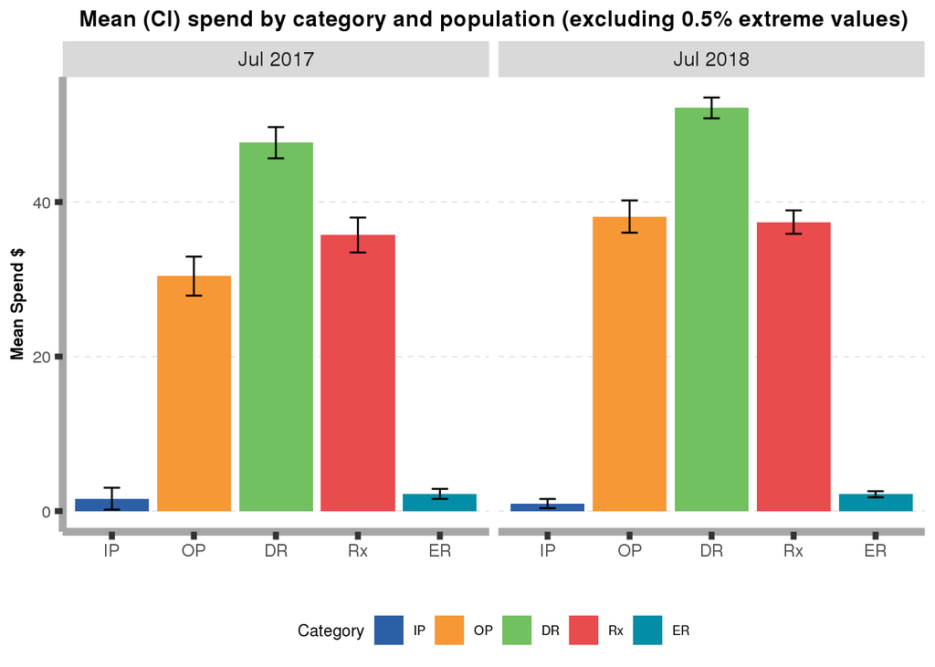

The PMPM dollar amounts from the curent month July of the year back to July month of the prior year were also calculated to compare the spending for the different services over the one year period.

PMPM $ spending for each population

| Group | Months | IP | OP | DR | Rx | ER | Total | Members |
| --- | --- | --- | --- | --- | --- | --- | --- | --- |
| Population 1 | 77,591 | 97.1 | 118.2 | 82.3 | 68.9 | 30.5 | 397.0 | 14,071 |
| Population 2 | 246,033 | 107.2 | 124.8 | 89.3 | 82.3 | 29.9 | 433.3 | 36,438 |

## Enrolled

### Demographics

Effect size of the difference

| Variable | Estimate | Magnitude |
| --- | --- | --- |
| Age | 0.077 | negligible |
| Median Household Income | 0.052 | negligible |

|  | July 2017 (N=9730) | July 2018 (N=16672) | p value |
| --- | --- | --- | --- |
| **Age** |  |  | < 0.001 |
| Median (Q1, Q3) | 44.00 (35.00, 54.00) | 43.00 (34.00, 53.00) |  |
| Mean (SD) | 44.16 (11.46) | 43.28 (11.41) |  |
| Range | 19.00 - 77.00 | 19.00 - 81.00 |  |
| **Gender** |  |  | < 0.001 |
| N-Miss | 0 | 1 |  |
| F | 4711 (48.4%) | 8755 (52.5%) |  |
| M | 5019 (51.6%) | 7916 (47.5%) |  |
| **Subscriber** | 7672 (78.8%) | 13708 (82.2%) | < 0.001 |
| **Area** |  |  | < 0.001 |
| N-Miss | 21 | 19 |  |
| U | 3012 (31.0%) | 5358 (32.2%) |  |
| S | 4130 (42.5%) | 7770 (46.7%) |  |
| R | 2567 (26.4%) | 3525 (21.2%) |  |
| **Median Household Income** |  |  | < 0.001 |
| N-Miss | 23 | 23 |  |
| Median (Q1, Q3) | 55630.00 (44022.50, 73767.00) | 57348.00 (44638.00, 74970.00) |  |
| Mean (SD) | 60887.56 (22951.85) | 62110.92 (23603.52) |  |
| Range | 11021.00 - 217171.00 | 11021.00 - 250001.00 |  |

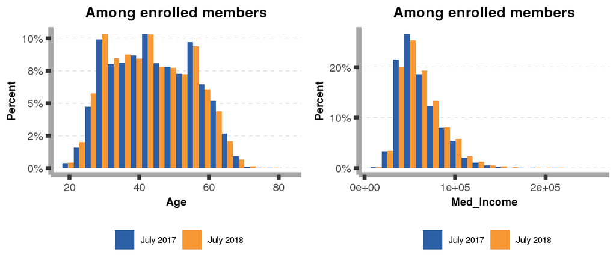

### Health

|  | July 2017 (N=9730) | July 2018 (N=16672) | p value |
| --- | --- | --- | --- |
| **Type 2 Diabetes** | 54 (0.6%) | 96 (0.6%) | 0.828 |
| **Hypertension** | 250 (2.6%) | 458 (2.7%) | 0.388 |
| **Depression / Anxiety** | 167 (1.7%) | 305 (1.8%) | 0.504 |
| **COPD** | 12 (0.1%) | 13 (0.1%) | 0.248 |
| **CHF** | 2 (0.0%) | 11 (0.1%) | 0.108 |
| **RA** | 3 (0.0%) | 9 (0.1%) | 0.395 |
| **Chronic Pain** | 349 (3.6%) | 612 (3.7%) | 0.725 |
| **RAF Score** |  |  | 0.012 |
| N-Miss | 0 | 1 |  |
| Median (Q1, Q3) | 0.49 (0.29, 0.70) | 0.49 (0.30, 0.70) |  |
| Mean (SD) | 1.21 (4.09) | 1.09 (3.55) |  |
| Range | 0.14 - 185.14 | 0.14 - 185.14 |  |

RAF score and percentage prevalence

|  | July 2017 (N=9730) | July 2018 (N=16672) | p value |
| --- | --- | --- | --- |
| **Type 2 Diabetes** | 54 (0.6%) | 96 (0.6%) | 0.828 |
| **Hypertension** | 250 (2.6%) | 458 (2.7%) | 0.388 |
| **Depression / Anxiety** | 167 (1.7%) | 305 (1.8%) | 0.504 |
| **COPD** | 12 (0.1%) | 13 (0.1%) | 0.248 |
| **CHF** | 2 (0.0%) | 11 (0.1%) | 0.108 |
| **RA** | 3 (0.0%) | 9 (0.1%) | 0.395 |
| **Chronic Pain** | 349 (3.6%) | 612 (3.7%) | 0.725 |
| **RAF Score** |  |  | 0.012 |
| N-Miss | 0 | 1 |  |
| Median (Q1, Q3) | 0.49 (0.29, 0.70) | 0.49 (0.30, 0.70) |  |
| Mean (SD) | 1.21 (4.09) | 1.09 (3.55) |  |
| Range | 0.14 - 185.14 | 0.14 - 185.14 |  |

RAF score (excluding 0.1% extreme normalized values)

|  | July 2017 (N=9730) | July 2018 (N=16672) | p_value |
| --- | --- | --- | --- |
| **RAF Score** |  |  | < 0.001 |
| Nmiss | 0 | 1 |  |
| N-outliers | 98 | 163 |  |
| Median (Q1, Q3) | 0.49 (0.29, 0.70) | 0.49 (0.29, 0.70) |  |
| Mean (SD) | 0.91 (1.45) | 0.83 (1.27) |  |
| Range | 0.14 - 13.8 | 0.14 - 11.96 |  |

To examine the prevalence further, continuous UHC plan enrollment from January to July of the corresponding year was considered. The prevalence of hypertension, depression or anxiety, and chronic pain conditions are higher among those enrolled in July 2018 than those enrolled in July 2017 by 1%, 1%, and 1.2%, respectively.

Jan - July percentage prevalence

|  | July 2017 (N=9730) | July 2018 (N=16672) | p value |
| --- | --- | --- | --- |
| **T2D_Flag** | 54 (0.6%) | 96 (0.6%) | 0.828<sup>1</sup> |
| **Hypertension_Flag** | 905 (9.3%) | 1725 (10.3%) | 0.006<sup>1</sup> |
| **Dep_Anx_Flag** | 610 (6.3%) | 1209 (7.3%) | 0.002<sup>1</sup> |
| **COPD_Flag** | 46 (0.5%) | 73 (0.4%) | 0.683<sup>1</sup> |
| **CHF_Flag** | 12 (0.1%) | 32 (0.2%) | 0.187<sup>1</sup> |
| **RA_Flag** | 14 (0.1%) | 26 (0.2%) | 0.808<sup>1</sup> |
| **ChronicPain_Flag** | 1054 (10.8%) | 2007 (12.0%) | 0.003<sup>1</sup> |

1. Pearson’s Chi-squared test

Effect size of the difference

| Variable | Estimate | Magnitude |
| --- | --- | --- |
| Hypertension | 0.035 | negligible |
| Depression / Anxiety | 0.039 | negligible |
| Chronic pain | 0.038 | negligible |

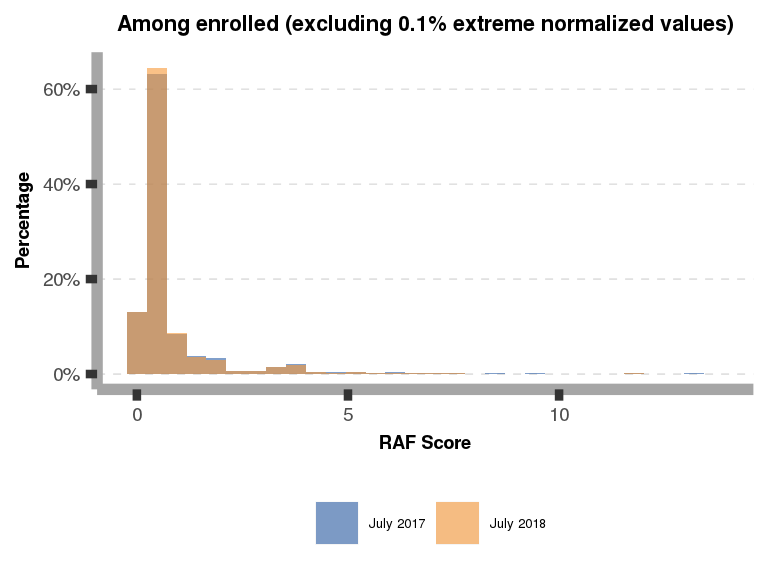

### Claims

Enrolled members in July 2018 had higher OP, DR, and total dollar spending than the July 2017 enrolled members, but the differences were negligible.

Comparison of healthcare $ spending

|  | July 2017 (N=9730) | July 2018 (N=16672) | p value |
| --- | --- | --- | --- |
| **IP** |  |  | 0.498 |
| Mean (SD) | 95.79 (1775.13) | 80.94 (1685.29) |  |
| Range | 0.00 - 98023.72 | 0.00 - 85843.40 |  |
| **OP** |  |  | 0.146 |
| Mean (SD) | 101.52 (882.46) | 122.47 (1250.58) |  |
| Range | 0.00 - 19968.17 | 0.00 - 47591.66 |  |
| **DR** |  |  | 0.037 |
| Mean (SD) | 76.03 (322.26) | 85.19 (357.15) |  |
| Range | 0.00 - 8855.84 | 0.00 - 17708.18 |  |
| **Rx** |  |  | 0.595 |
| Mean (SD) | 75.68 (638.64) | 79.68 (560.10) |  |
| Range | 0.00 - 25119.36 | 0.00 - 23634.49 |  |
| **ER** |  |  | 0.518 |
| Mean (SD) | 32.16 (351.43) | 29.33 (337.69) |  |
| Range | 0.00 - 10550.58 | 0.00 - 10552.80 |  |
| **Total** |  |  | 0.589 |
| Mean (SD) | 381.16 (2345.27) | 397.61 (2414.21) |  |
| Range | 0.00 - 100693.77 | 0.00 - 86386.23 |  |

Comparison of healthcare $ spending (exluding 0.5% extreme values)

|  | July 2017 (N=9730) | July 2018 (N=16672) | p_value |
| --- | --- | --- | --- |
| **IP** |  |  | 0.600 |
| N-outliers | 43 | 58 |  |
| Mean (SD) | 0.66 (47.08) | 0.39 (34.15) |  |
| Range | 0 - 3982.62 | 0 - 4181.02 |  |
| **OP** |  |  | < 0.001 |
| N-outliers | 89 | 136 |  |
| Mean (SD) | 30.2 (149.68) | 39.42 (206.13) |  |
| Range | 0 - 2285.97 | 0 - 3289.7 |  |
| **DR** |  |  | < 0.001 |
| N-outliers | 127 | 231 |  |
| Mean (SD) | 48.48 (120.99) | 54.54 (130.49) |  |
| Range | 0 - 899.6 | 0 - 1002.42 |  |
| **Rx** |  |  | 0.857 |
| N-outliers | 67 | 180 |  |
| Mean (SD) | 35.51 (135.07) | 35.81 (129.07) |  |
| Range | 0 - 1694.57 | 0 - 1513.32 |  |
| **ER** |  |  | 0.083 |
| N-outliers | 101 | 163 |  |
| Mean (SD) | 2.26 (38.32) | 1.51 (30.43) |  |
| Range | 0 - 901.99 | 0 - 894.3 |  |
| **Total** |  |  | < 0.001 |
| N-outliers | 126 | 198 |  |
| Mean (SD) | 171.32 (549.6) | 198.02 (610.67) |  |
| Range | 0 - 6404.15 | 0 - 6522.1 |  |

Effect size of the difference

| Spend | Estimate | Magnitude |
| --- | --- | --- |
| OP | 0.049 | negligible |
| DR | 0.048 | negligible |
| Total | 0.045 | negligible |

Enrolled Count and Total Spend

| Year_Mo_ | N | Mean Total Spend | SD Total Spend |
| --- | --- | --- | --- |
| Jul 2017 | 9,604 | 171.3 | 549.6 |
| Jul 2018 | 16,474 | 198.0 | 610.7 |

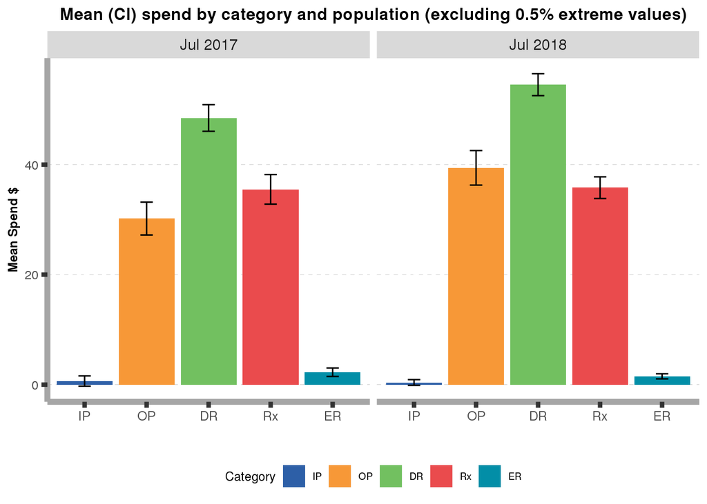

PMPM $ spending for each population

| Group | Months | IP | OP | DR | Rx | ER | Total | Members |
| --- | --- | --- | --- | --- | --- | --- | --- | --- |
| Population 1 | 53,442 | 80.1 | 106 | 78.9 | 68.3 | 28.0 | 361.3 | 9,730 |
| Population 2 | 136,075 | 95.4 | 125 | 90.8 | 81.5 | 26.9 | 419.6 | 16,672 |

## Active

#### Among Eligible

Active Rate of Current Month and Current Month Year Ago

| Year Month | Active | Inactive | Active Rate % |
| --- | --- | --- | --- |
| July 2017 | 6775 | 7296 | 48.15 |
| July 2018 | 8884 | 27548 | 24.39 |

###### Demographics

Demographic Comparisons

|  | July 2017 (N=6775) | July 2018 (N=8884) | p value |
| --- | --- | --- | --- |
| **Age** |  |  | < 0.01<sup>1</sup> |
| Mean (SD) | 45.09 (11.28) | 44.55 (11.10) |  |
| Range | 19.00 - 77.00 | 19.00 - 78.00 |  |
| **Gender** |  |  | < 0.01<sup>2</sup> |
| N-Miss | 0 | 1 |  |
| F | 3282 (48.4%) | 4809 (54.1%) |  |
| M | 3493 (51.6%) | 4074 (45.9%) |  |
| **Subscriber** |  |  | < 0.01<sup>1</sup> |
| Mean (SD) | 0.79 (0.41) | 0.82 (0.38) |  |
| Range | 0.00 - 1.00 | 0.00 - 1.00 |  |
| **Area** |  |  | < 0.01<sup>2</sup> |
| N-Miss | 13 | 6 |  |
| R | 1728 (25.6%) | 1759 (19.8%) |  |
| S | 2881 (42.6%) | 4259 (48.0%) |  |
| U | 2153 (31.8%) | 2860 (32.2%) |  |
| **Median Income** |  |  | < 0.01<sup>1</sup> |
| N-Miss | 14 | 8 |  |
| Mean (SD) | 61299.64 (22992.82) | 63282.93 (23838.75) |  |
| Range | 11021.00 - 217171.00 | 11021.00 - 217171.00 |  |
| **RAF Score** |  |  | < 0.01<sup>1</sup> |
| N-Miss | 0 | 1 |  |
| Mean (SD) | 0.79 (2.19) | 1.06 (3.58) |  |
| Range | 0.06 - 86.61 | 0.06 - 185.14 |  |

1. Linear Model ANOVA
2. Pearson’s Chi-squared test

Median Income and RAF Score Comparisons (excluding 0.5% extreme values)

|  | July 2017 (N=6775) | July 2018 (N=8884) | p_value |
| --- | --- | --- | --- |
| **Median Income** |  |  | < 0.01 |
| N-Outliers | 108 | 156 |  |
| Mean (SD) | 59975.83 (20495.65) | 61840.87 (21277.37) |  |
| Range | 11021 - 120496 | 11021 - 124231 |  |
| **RAF Score** |  |  | < 0.01 |
| N-Outliers | 76 | 98 |  |
| Mean (SD) | 0.62 (0.73) | 0.79 (1.15) |  |
| Range | 0.06 - 6.33 | 0.06 - 10.28 |  |

Effect Size

| Variable | July 2017 | July 2018 | Cohen.s.D.Estimate | Magnitude |
| --- | --- | --- | --- | --- |
| Age | 45.09 (11.28) | 44.55 (11.1) | 0.0489300 | negligible |
| Med_Income | 59975.83 (20495.65) | 61840.87 (21277.37) | 0.0890546 | negligible |
| RAF_Score | 0.62 (0.73) | 0.79 (1.15) | 0.1705744 | negligible |

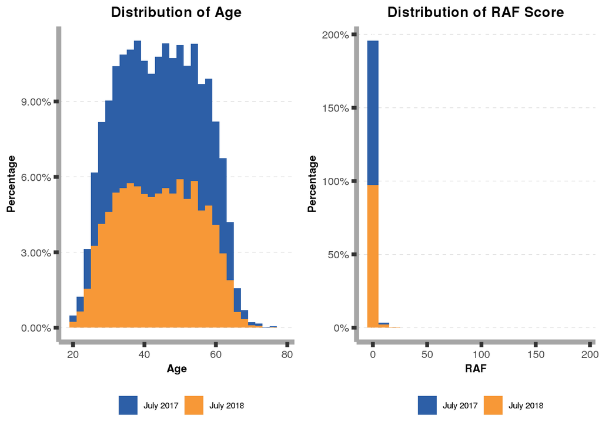

###### Health

Prevalence of Conditions (July only)

|  | July 2017 (N=6775) | July 2018 (N=8884) | p value |
| --- | --- | --- | --- |
| **Type 2 Diabetes** | 35 (0.5%) | 45 (0.5%) | 0.93<sup>1</sup> |
| **Hypertension** | 187 (2.8%) | 249 (2.8%) | 0.87<sup>1</sup> |
| **Depression and Anxiety** | 105 (1.5%) | 157 (1.8%) | 0.29<sup>1</sup> |
| **COPD** | 8 (0.1%) | 7 (0.1%) | 0.43<sup>1</sup> |
| **Congestive Heart Failure** | 1 (0.0%) | 3 (0.0%) | 0.46<sup>1</sup> |
| **Rheumatoid Athritis** | 2 (0.0%) | 3 (0.0%) | 0.88<sup>1</sup> |
| **Chronic Pain** | 250 (3.7%) | 315 (3.5%) | 0.63<sup>1</sup> |

1. Pearson’s Chi-squared test

Prevalence of Conditions (Jan-July)

|  | July 2017 (N=6775) | July 2018 (N=8884) | p value |
| --- | --- | --- | --- |
| **Type 2 Diabetes** | 35 (0.5%) | 45 (0.5%) | 0.93<sup>1</sup> |
| **Hypertension** | 656 (9.7%) | 961 (10.8%) | 0.02<sup>1</sup> |
| **Depression and Anxiety** | 377 (5.6%) | 572 (6.4%) | 0.02<sup>1</sup> |
| **COPD** | 27 (0.4%) | 36 (0.4%) | 0.95<sup>1</sup> |
| **Congestive Heart Failure** | 7 (0.1%) | 14 (0.2%) | 0.36<sup>1</sup> |
| **Rheumatoid Athritis** | 8 (0.1%) | 7 (0.1%) | 0.43<sup>1</sup> |
| **Chronic Pain** | 694 (10.2%) | 1012 (11.4%) | 0.02<sup>1</sup> |

1. Pearson’s Chi-squared test

Effect Size

| Variable | July 2017 (N=6775) | July 2018 (N=8884) | Cohen.s.H.Estimate | Magnitude |
| --- | --- | --- | --- | --- |
| Hypertension_Flag | 656 (9.7%) | 961 (10.8%) | 0.0374196 | negligible |
| Dep_Anx_Flag | 377 (5.6%) | 572 (6.4%) | 0.0368196 | negligible |
| ChronicPain_Flag | 694 (10.2%) | 1012 (11.4%) | 0.0369639 | negligible |

###### Claims

Claims Spending Comparison

|  | July 2017 (N=6775) | July 2018 (N=8884) | p value |
| --- | --- | --- | --- |
| **IP** |  |  | 0.10<sup>1</sup> |
| Mean (SD) | 97.24 (1910.22) | 55.37 (1224.18) |  |
| Range | 0.00 - 98023.72 | 0.00 - 46551.66 |  |
| **OP** |  |  | 0.03<sup>1</sup> |
| Mean (SD) | 95.75 (851.16) | 136.40 (1378.75) |  |
| Range | 0.00 - 17155.84 | 0.00 - 47591.66 |  |
| **DR** |  |  | < 0.01<sup>1</sup> |
| Mean (SD) | 74.92 (325.47) | 91.68 (407.57) |  |
| Range | 0.00 - 8855.84 | 0.00 - 17708.18 |  |
| **RX** |  |  | 0.69<sup>1</sup> |
| Mean (SD) | 84.20 (733.51) | 80.10 (553.93) |  |
| Range | 0.00 - 25119.36 | 0.00 - 17277.41 |  |
| **ER** |  |  | 0.21<sup>1</sup> |
| Mean (SD) | 29.86 (324.67) | 23.51 (310.78) |  |
| Range | 0.00 - 7972.22 | 0.00 - 10552.80 |  |
| **Total Allowed Amount** |  |  | 0.89<sup>1</sup> |
| Mean (SD) | 381.94 (2417.31) | 387.05 (2180.48) |  |
| Range | 0.00 - 100693.77 | 0.00 - 66226.70 |  |

1. Linear Model ANOVA

Claims Spending Comparison(excluding 0.5% extreme values)

|  | July 2017 (N=6775) | July 2018 (N=8884) | p_value |
| --- | --- | --- | --- |
| **IP** |  |  | 0.60<sup>1</sup> |
| N-Outliers | 28 | 25 |  |
| Mean (SD) | 0.35 (28.83) | 0.17 (12.47) |  |
| Range | 0 - 2368.43 | 0 - 1101.47 |  |
| **OP** |  |  | < 0.01<sup>1</sup> |
| N-Outliers | 56 | 73 |  |
| Mean (SD) | 29.49 (147.01) | 43.62 (228.83) |  |
| Range | 0 - 2285.97 | 0 - 3624 |  |
| **DR** |  |  | < 0.01<sup>1</sup> |
| N-Outliers | 78 | 112 |  |
| Mean (SD) | 48.68 (120.62) | 58.81 (140.51) |  |
| Range | 0 - 899.6 | 0 - 1140.8 |  |
| **RX** |  |  | 0.37<sup>1</sup> |
| N-Outliers | 44 | 97 |  |
| Mean (SD) | 37.25 (144.05) | 35.3 (125.12) |  |
| Range | 0 - 1935.03 | 0 - 1506.42 |  |
| **ER** |  |  | 0.02<sup>1</sup> |
| N-Outliers | 69 | 72 |  |
| Mean (SD) | 2.09 (36.38) | 0.94 (23.52) |  |
| Range | 0 - 865.08 | 0 - 811.57 |  |
| **Total Allowed Amount** |  |  | 0.02<sup>1</sup> |
| N-Outliers | 88 | 118 |  |
| Mean (SD) | 169.88 (550.08) | 191.32 (563.87) |  |
| Range | 0 - 6562.55 | 0 - 5954.78 |  |

1. modified by user

Effect Size

| Variable | July 2017 | July 2018 | Cohen.s.D.Estimate | Magnitude |
| --- | --- | --- | --- | --- |
| OP_Allw_Amt | 29.49 (147.01) | 43.62 (228.83) | 0.0715174 | negligible |
| DR_Allw_Amt | 48.68 (120.62) | 58.81 (140.51) | 0.0766156 | negligible |
| ER_Allw_Amt | 2.09 (36.38) | 0.94 (23.52) | 0.0388492 | negligible |
| Total_Allw_Amt | 169.88 (550.08) | 191.32 (563.87) | 0.0384156 | negligible |

Per Member Per Month Claims Spending

| Year Month | PMPM ($) |
| --- | --- |
| July 2017 | 331.0312 |
| July 2018 | 385.6273 |

Bootstrap on the Difference in PMPM

| OBSERVED DIFFERENCE | 95% CI |
| --- | --- |
| 54.5961 | ( 6.18 , 101.45 ) |

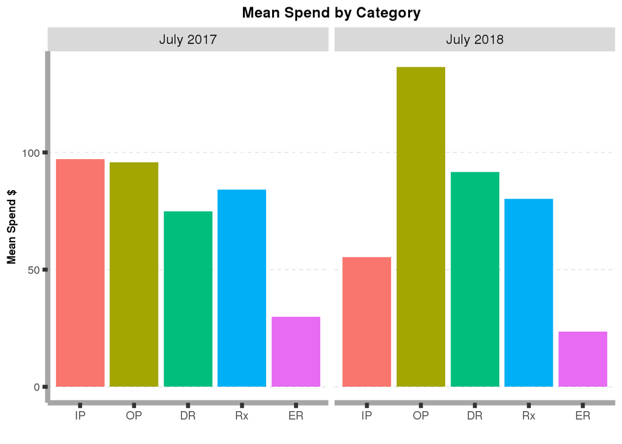

#### Among Enrolled

Active Rate of Current Month and Current Month Year Ago

| Year Month | Active | Inactive | Active Rate % |
| --- | --- | --- | --- |
| July 2017 | 6772 | 2958 | 69.60 |
| July 2018 | 8880 | 7792 | 53.26 |

###### Demographics

Demographic Comparisons

|  | July 2017 (N=6772) | July 2018 (N=8880) | p value |
| --- | --- | --- | --- |
| **Age** |  |  | < 0.01<sup>1</sup> |
| Mean (SD) | 45.10 (11.28) | 44.55 (11.11) |  |
| Range | 19.00 - 77.00 | 19.00 - 78.00 |  |
| **Gender** |  |  | < 0.01<sup>2</sup> |
| N-Miss | 0 | 1 |  |
| F | 3282 (48.5%) | 4807 (54.1%) |  |
| M | 3490 (51.5%) | 4072 (45.9%) |  |
| **Subscriber** |  |  | < 0.01<sup>1</sup> |
| Mean (SD) | 0.79 (0.41) | 0.82 (0.38) |  |
| Range | 0.00 - 1.00 | 0.00 - 1.00 |  |
| **Area** |  |  | < 0.01<sup>2</sup> |
| N-Miss | 13 | 6 |  |
| R | 1727 (25.6%) | 1758 (19.8%) |  |
| S | 2879 (42.6%) | 4258 (48.0%) |  |
| U | 2153 (31.9%) | 2858 (32.2%) |  |
| **Median Income** |  |  | < 0.01<sup>1</sup> |
| N-Miss | 14 | 8 |  |
| Mean (SD) | 61303.21 (22996.16) | 63288.62 (23839.85) |  |
| Range | 11021.00 - 217171.00 | 11021.00 - 217171.00 |  |
| **RAF Score** |  |  | < 0.01<sup>1</sup> |
| N-Miss | 0 | 1 |  |
| Mean (SD) | 0.79 (2.19) | 1.06 (3.58) |  |
| Range | 0.06 - 86.61 | 0.06 - 185.14 |  |

1. Linear Model ANOVA
2. Pearson’s Chi-squared test

Median Income and RAF Score Comparisons (excluding 0.5% extreme values)

|  | July 2017 (N=6772) | July 2018 (N=8880) | p_value |
| --- | --- | --- | --- |
| **Median Income** |  |  | < 0.01 |
| N-Outliers | 108 | 156 |  |
| Mean (SD) | 59978.86 (20498.47) | 61846 (21277.75) |  |
| Range | 11021 - 120496 | 11021 - 124231 |  |
| **RAF Score** |  |  | < 0.01 |
| N-Outliers | 76 | 98 |  |
| Mean (SD) | 0.63 (0.73) | 0.79 (1.15) |  |
| Range | 0.06 - 6.33 | 0.06 - 10.28 |  |

Effect Size

| Variable | July 2017 | July 2018 | Cohen.s.D.Estimate | Magnitude |
| --- | --- | --- | --- | --- |
| Age | 45.09 (11.28) | 44.55 (11.1) | 0.0489300 | negligible |
| Med_Income | 61299.64 (22992.82) | 63282.93 (23838.75) | 0.0844786 | negligible |
| RAF_Score | 0.79 (2.19) | 1.06 (3.58) | 0.0876535 | negligible |

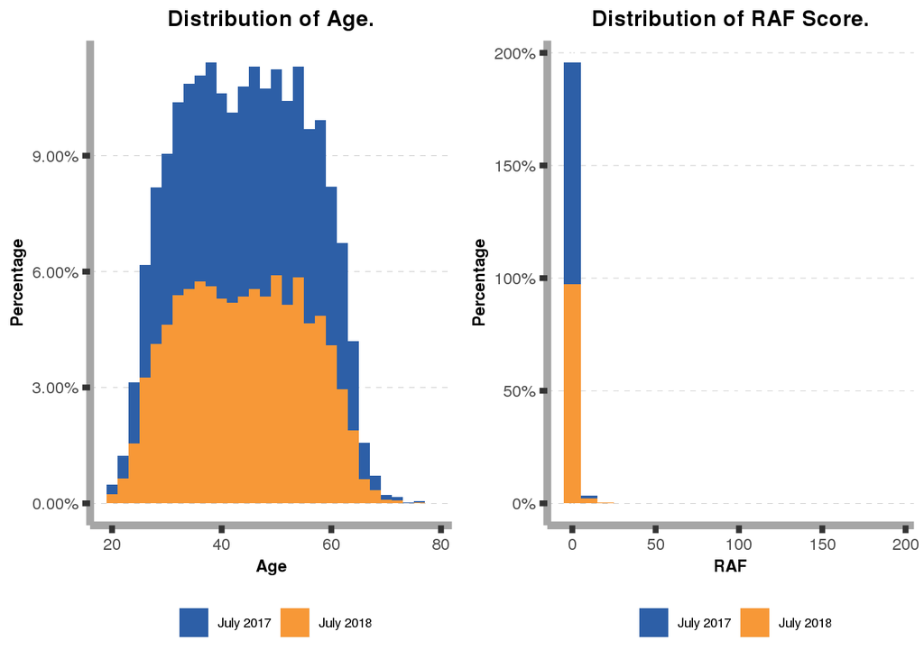

###### Health

Prevalence of Conditions (July only)

|  | July 2017 (N=6772) | July 2018 (N=8880) | p value |
| --- | --- | --- | --- |
| **Type 2 Diabetes** | 35 (0.5%) | 45 (0.5%) | 0.93<sup>1</sup> |
| **Hypertension** | 187 (2.8%) | 249 (2.8%) | 0.87<sup>1</sup> |
| **Depression and Anxiety** | 105 (1.6%) | 157 (1.8%) | 0.29<sup>1</sup> |
| **COPD** | 8 (0.1%) | 7 (0.1%) | 0.43<sup>1</sup> |
| **Congestive Heart Failure** | 1 (0.0%) | 3 (0.0%) | 0.46<sup>1</sup> |
| **Rheumatoid Athritis** | 2 (0.0%) | 3 (0.0%) | 0.88<sup>1</sup> |
| **Chronic Pain** | 250 (3.7%) | 315 (3.5%) | 0.63<sup>1</sup> |

1. Pearson’s Chi-squared test

Prevalence of Conditions (Jan-July)

|  | July 2017 (N=6772) | July 2018 (N=8880) | p value |
| --- | --- | --- | --- |
| **Type 2 Diabetes** | 35 (0.5%) | 45 (0.5%) | 0.93<sup>1</sup> |
| **Hypertension** | 656 (9.7%) | 961 (10.8%) | 0.02<sup>1</sup> |
| **Depression and Anxiety** | 377 (5.6%) | 572 (6.4%) | 0.02<sup>1</sup> |
| **COPD** | 27 (0.4%) | 36 (0.4%) | 0.95<sup>1</sup> |
| **Congestive Heart Failure** | 7 (0.1%) | 14 (0.2%) | 0.36<sup>1</sup> |
| **Rheumatoid Athritis** | 8 (0.1%) | 7 (0.1%) | 0.43<sup>1</sup> |
| **Chronic Pain** | 694 (10.2%) | 1012 (11.4%) | 0.02<sup>1</sup> |

1. Pearson’s Chi-squared test

Effect Size

| Variable | July 2017 (N=6772) | July 2018 (N=8880) | Cohen.s.H.Estimate | Magnitude |
| --- | --- | --- | --- | --- |
| Hypertension_Flag | 656 (9.7%) | 961 (10.8%) | 0.0374314 | negligible |
| Dep_Anx_Flag | 377 (5.6%) | 572 (6.4%) | 0.0368302 | negligible |
| ChronicPain_Flag | 694 (10.2%) | 1012 (11.4%) | 0.0369758 | negligible |

###### Claims

Claims Spending Comparison

|  | July 2017 (N=6772) | July 2018 (N=8880) | p value |
| --- | --- | --- | --- |
| **IP** |  |  | 0.10<sup>1</sup> |
| Mean (SD) | 97.29 (1910.64) | 55.40 (1224.46) |  |
| Range | 0.00 - 98023.72 | 0.00 - 46551.66 |  |
| **OP** |  |  | 0.03<sup>1</sup> |
| Mean (SD) | 95.79 (851.35) | 136.43 (1379.06) |  |
| Range | 0.00 - 17155.84 | 0.00 - 47591.66 |  |
| **DR** |  |  | < 0.01<sup>1</sup> |
| Mean (SD) | 74.95 (325.54) | 91.72 (407.66) |  |
| Range | 0.00 - 8855.84 | 0.00 - 17708.18 |  |
| **RX** |  |  | 0.69<sup>1</sup> |
| Mean (SD) | 84.24 (733.67) | 80.13 (554.06) |  |
| Range | 0.00 - 25119.36 | 0.00 - 17277.41 |  |
| **ER** |  |  | 0.21<sup>1</sup> |
| Mean (SD) | 29.87 (324.74) | 23.52 (310.85) |  |
| Range | 0.00 - 7972.22 | 0.00 - 10552.80 |  |
| **Total Allowed Amount** |  |  | 0.89<sup>1</sup> |
| Mean (SD) | 382.11 (2417.83) | 387.20 (2180.96) |  |
| Range | 0.00 - 100693.77 | 0.00 - 66226.70 |  |

1. Linear Model ANOVA

Claims Spending Comparison (excluding 0.5% extreme values)

|  | July 2017 (N=6772) | July 2018 (N=8880) | p_value |
| --- | --- | --- | --- |
| **IP** |  |  | 0.60<sup>1</sup> |
| N-Outliers | 28 | 25 |  |
| Mean (SD) | 0.35 (28.84) | 0.17 (12.47) |  |
| Range | 0 - 2368.43 | 0 - 1101.47 |  |
| **OP** |  |  | < 0.01<sup>1</sup> |
| N-Outliers | 56 | 73 |  |
| Mean (SD) | 29.5 (147.04) | 43.61 (228.87) |  |
| Range | 0 - 2285.97 | 0 - 3624 |  |
| **DR** |  |  | < 0.01<sup>1</sup> |
| N-Outliers | 78 | 112 |  |
| Mean (SD) | 48.7 (120.65) | 58.84 (140.54) |  |
| Range | 0 - 899.6 | 0 - 1140.8 |  |
| **RX** |  |  | 0.37<sup>1</sup> |
| N-Outliers | 44 | 97 |  |
| Mean (SD) | 37.26 (144.08) | 35.31 (125.14) |  |
| Range | 0 - 1935.03 | 0 - 1506.42 |  |
| **ER** |  |  | 0.02<sup>1</sup> |
| N-Outliers | 69 | 72 |  |
| Mean (SD) | 2.09 (36.39) | 0.94 (23.52) |  |
| Range | 0 - 865.08 | 0 - 811.57 |  |
| **Total Allowed Amount** |  |  | 0.02<sup>1</sup> |
| N-Outliers | 88 | 118 |  |
| Mean (SD) | 169.96 (550.19) | 191.37 (563.99) |  |
| Range | 0 - 6562.55 | 0 - 5954.78 |  |

1. modified by user

Effect Size

| Variable | July 2017 | July 2018 | Cohen.s.D.Estimate | Magnitude |
| --- | --- | --- | --- | --- |
| OP_Allw_Amt | 29.5 (147.04) | 43.61 (228.87) | 0.0713970 | negligible |
| DR_Allw_Amt | 48.7 (120.65) | 58.84 (140.54) | 0.0766392 | negligible |
| ER_Allw_Amt | 2.09 (36.39) | 0.94 (23.52) | 0.0388577 | negligible |
| Total_Allw_Amt | 169.96 (550.19) | 191.37 (563.99) | 0.0383775 | negligible |

Per Member Per Month Claims Spending

| Year Month | PMPM ($) |
| --- | --- |
| July 2017 | 330.9293 |
| July 2018 | 385.8003 |

Bootstrap on the Difference in PMPM.

| OBSERVED DIFFERENCE | 95% CI |
| --- | --- |
| 54.87099 | ( 7.54 , 102.32 ) |

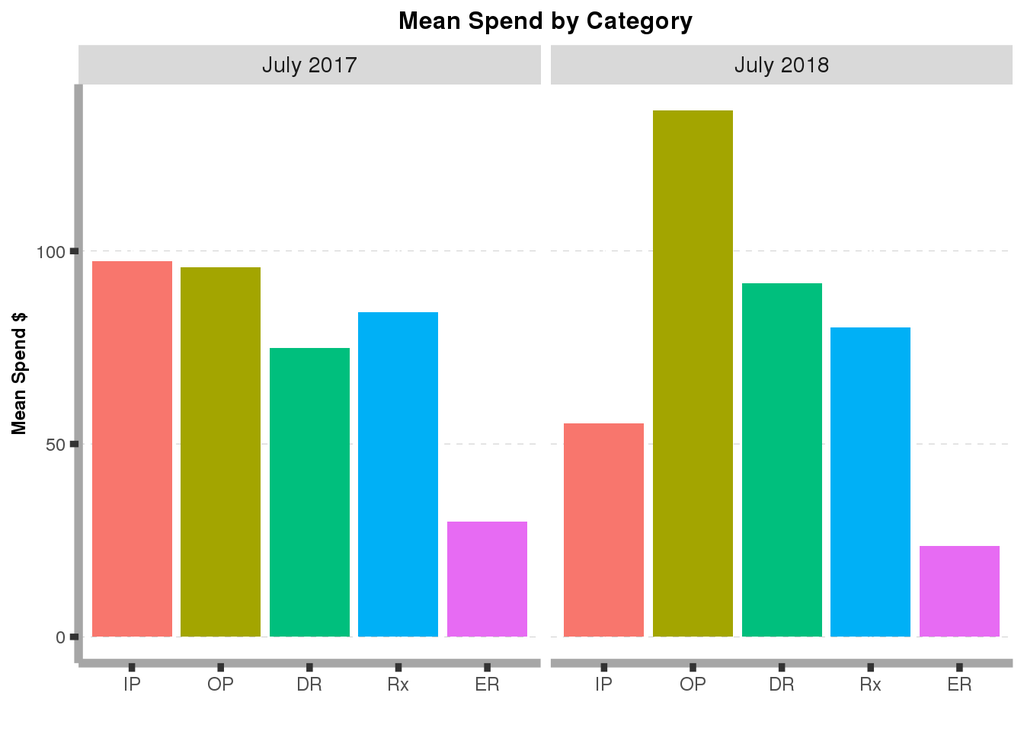

# Conclusion

Others to follow.

# Appendix

```r
# Number of individuals enrolled in UHC per Group and year month
mm[Group1_Flag == 1 , .N, .(Indv_Sys_ID, Year_Mo)][,.N, keyby = Year_Mo][Year_Mo <= 201707]
```

```
##     Year_Mo     N
##  1:  201607   941
##  2:  201608  1017
##  3:  201609  1360
##  4:  201610  1629
##  5:  201611  1877
##  6:  201612  2007
##  7:  201701  7531
##  8:  201702  7737
##  9:  201703  8071
## 10:  201704  9544
## 11:  201705 10723
## 12:  201706 12635
## 13:  201707 14071
```

```r
mm[Group2_Flag == 1 , .N, .(Indv_Sys_ID, Year_Mo)][,.N, keyby = Year_Mo][Year_Mo >= 201707]
```

```
##     Year_Mo     N
##  1:  201707 11282
##  2:  201708 12479
##  3:  201709 12580
##  4:  201710 13248
##  5:  201711 13509
##  6:  201712 13528
##  7:  201801 24178
##  8:  201802 24332
##  9:  201803 25825
## 10:  201804 27674
## 11:  201805 29569
## 12:  201806 31372
## 13:  201807 36438
```

```r
# count_mm =
# ggplot(mm[Group1_Flag == 1], aes(x = as.Date(Year_Mo_))) +
#   geom_line(aes)
```